# New variance component test for SNP set analysis

Based on the oringinal tutorial, this one changes a new dataset for SNP 24 and focuses on genes with 3 or more SNPs.

## Check version

```julia
versioninfo()
```

```
Julia Version 1.1.0
Commit 80516ca202 (2019-01-21 21:24 UTC)
Platform Info:
  OS: macOS (x86_64-apple-darwin14.5.0)
  CPU: Intel(R) Core(TM) i7-6567U CPU @ 3.30GHz
  WORD_SIZE: 64
  LIBM: libopenlibm
  LLVM: libLLVM-6.0.1 (ORCJIT, skylake)
```

## Install packages when first use

You need to have the statistial software R and R package "pracma" installed.

```julia
using Pkg
Pkg.add(PackageSpec(url="https://github.com/OpenMendel/SnpArrays.jl.git"))
Pkg.add(PackageSpec(url="https://github.com/jinjinzhou/VarianceComponentTest.jl.git"))
Pkg.add(PackageSpec(url="https://github.com/OpenMendel/MendelPlots.jl.git"))
```

## Use packages

```julia
using SnpArrays
using CSV
using DataFrames, Query
using Distributions, DelimitedFiles, LinearAlgebra
using VarianceComponentTest
using StatsModels, Random, StatsBase, TraitSimulation
using Random
```

```
┌ Info: Recompiling stale cache file /Users/janets/.julia/compiled/v1.1/Query/wGX7b.ji for Query [1a8c2f83-1ff3-5112-b086-8aa67b057ba1]
└ @ Base loading.jl:1184
┌ Info: Recompiling stale cache file /Users/janets/.julia/compiled/v1.1/VarianceComponentTest/QfNDj.ji for VarianceComponentTest [1b8b39c6-5c46-50f5-9c36-ac18d7f28ae0]
└ @ Base loading.jl:1184
┌ Info: Recompiling stale cache file /Users/janets/.julia/compiled/v1.1/TraitSimulation/VikWX.ji for TraitSimulation [dec3038e-29bc-11e9-2207-9f3d5855a202]
└ @ Base loading.jl:1184
```

## Reproducibility

We set a random seed using the Random.jl package for reproducibility. If you wish to end up with different data, you will need to comment out these commands or use another value in Random.seed!().

```julia
Random.seed!(100);
```

## Enter the folder path

```julia
;pwd
```

```
/Users/janets/Documents/lap_top_janet/janet/genetics/variance_components/Ruoyao_notebooksAugust2019/newvctest/VCtest_24_input_file
```

You can change the folder path according to your own computer. For example:

```julia
;cd /Users/apple/Desktop/Julia/VCtest_24
```

## Load and filter missing value of the definition file

The gene annotation is contained in the definition file in the last (sixth) column. This data is from Option 24 of the Mendel data.

```julia
df= (CSV.read("SNP_def24a.in",header=false))[:,[1,2,3,6]]
chromosomes = df[:, 2]
AdjBasepairs = df[:,3]
genes = df[:, end];
```

Set missing value as -1 and count the number of unique genes because we are only interested in genes with 3 or more snps.

```julia
genes[ismissing.(genes)] .= -1 # missing value as -1
chromosomes[ismissing.(genes)] .= -1
uniquegenes = unique(genes)
genes_number = length(uniquegenes)
```

```
4824
```

## Read in plink format genotype files

Read three files containing information about the names of snps, locations and phenotype messages.

```julia
plinkFile = "SNP_24"
## parse data from files
plinkBedfile = string(plinkFile, ".bed");
plinkBimfile = string(plinkFile, ".bim");
plinkFamfile = string(plinkFile, ".fam");
SNP_24 = SnpData("SNP_24");
```

```julia
# BIM file: chr, rs#, morgan, bp position, allele1, allele2
bimdata = readdlm(plinkBimfile, String);
chrID = bimdata[:, 1];
snpID = bimdata[:, 2];
snpPos = bimdata[:, 4];
nSNP = length(snpID);
```

```julia
# FAM file: fam ID, ind ID, father ID, mother ID, sex, phenotype
famdata = readdlm(plinkFamfile,',')
nPer = length(famdata[:, 1])
Fam_Person_id = DataFrame(FamID = famdata[:,1],PID =famdata[:,2])
```

|  | FamID Any | PID Any |
| --- | --- | --- |
| 1 | 1 | 1 |
| 2 | 2 | 1 |
| 3 | 3 | 1 |
| 4 | 4 | 1 |
| 5 | 5 | 1 |
| 6 | 6 | 1 |
| 7 | 7 | 1 |
| 8 | 8 | 1 |
| 9 | 9 | 1 |
| 10 | 10 | 1 |
| 11 | 11 | 1 |
| 12 | 12 | 1 |
| 13 | 13 | 1 |
| 14 | 14 | 1 |
| 15 | 15 | 1 |
| 16 | 16 | 1 |
| 17 | 17 | 1 |
| 18 | 18 | 1 |
| 19 | 19 | 1 |
| 20 | 20 | 1 |
| 21 | 21 | 1 |
| 22 | 22 | 1 |
| 23 | 23 | 1 |
| 24 | 24 | 1 |
| 25 | 25 | 1 |
| 26 | 26 | 1 |
| 27 | 27 | 1 |
| 28 | 28 | 1 |
| 29 | 29 | 1 |
| 30 | 30 | 1 |
| ⋮ | ⋮ | ⋮ |

## Trait Simulation

```julia
snpdata = SnpArray("Snp_24.bed")
```

```
2200×10000 SnpArray:
 0x02  0x03  0x03  0x00  0x02  0x03  …  0x02  0x03  0x03  0x03  0x02  0x03
 0x02  0x02  0x03  0x02  0x02  0x03     0x03  0x02  0x02  0x03  0x02  0x02
 0x03  0x02  0x03  0x02  0x02  0x03     0x03  0x02  0x02  0x02  0x02  0x03
 0x03  0x02  0x03  0x02  0x03  0x03     0x03  0x00  0x03  0x03  0x03  0x02
 0x03  0x03  0x03  0x00  0x02  0x03     0x03  0x03  0x03  0x03  0x02  0x03
 0x03  0x02  0x03  0x02  0x03  0x03  …  0x03  0x03  0x03  0x03  0x02  0x03
 0x03  0x02  0x02  0x02  0x03  0x03     0x02  0x00  0x02  0x03  0x02  0x02
 0x03  0x00  0x02  0x03  0x00  0x03     0x03  0x02  0x02  0x03  0x02  0x03
 0x03  0x02  0x00  0x02  0x02  0x03     0x03  0x02  0x03  0x03  0x02  0x03
 0x03  0x02  0x03  0x02  0x03  0x03     0x02  0x03  0x03  0x03  0x03  0x03
 0x02  0x02  0x02  0x00  0x03  0x03  …  0x03  0x03  0x03  0x03  0x02  0x02
 0x03  0x03  0x03  0x00  0x03  0x03     0x02  0x00  0x00  0x02  0x03  0x02
 0x02  0x02  0x03  0x02  0x02  0x03     0x03  0x03  0x02  0x03  0x03  0x03
    ⋮                             ⋮  ⋱           ⋮
 0x03  0x03  0x02  0x03  0x03  0x03     0x02  0x03  0x02  0x03  0x02  0x02
 0x03  0x02  0x03  0x03  0x03  0x03     0x02  0x02  0x02  0x03  0x02  0x02
 0x03  0x02  0x00  0x02  0x02  0x03  …  0x03  0x02  0x03  0x03  0x03  0x02
 0x03  0x02  0x03  0x00  0x02  0x03     0x03  0x03  0x03  0x03  0x03  0x02
 0x00  0x03  0x02  0x03  0x03  0x03     0x03  0x03  0x03  0x03  0x03  0x03
 0x02  0x03  0x03  0x02  0x02  0x03     0x02  0x00  0x00  0x02  0x02  0x03
 0x02  0x02  0x03  0x00  0x03  0x03     0x02  0x03  0x03  0x03  0x02  0x02
 0x02  0x02  0x02  0x02  0x02  0x03  …  0x00  0x03  0x03  0x03  0x02  0x03
 0x03  0x02  0x03  0x03  0x03  0x03     0x03  0x00  0x00  0x03  0x02  0x02
 0x03  0x02  0x03  0x03  0x03  0x02     0x03  0x02  0x02  0x03  0x03  0x02
 0x03  0x03  0x02  0x00  0x00  0x02     0x02  0x03  0x03  0x03  0x00  0x03
 0x03  0x03  0x03  0x00  0x03  0x03     0x03  0x03  0x00  0x03  0x03  0x02
```

```julia
snpdef24 = readdlm("SNP_24.bim";header = false)
snpid = map(x -> strip(string(x)), snpdef24[:, 2])
```

```
10000-element Array{SubString{String},1}:
 "rs3934834"
 "rs6603793"
 "rs2843153"
 "rs7535528"
 "rs12046158"
 "rs2817134"
 "rs4494089"
 "rs4648505"
 "rs1181883"
 "rs10915433"
 "rs4609397"
 "rs600933"
 "rs350187"
 ⋮
 "rs135720"
 "rs138407"
 "rs2413552"
 "rs139426"
 "rs137636"
 "rs132572"
 "rs137948"
 "rs739182"
 "rs12159200"
 "rs9611502"
 "rs6519287"
 "rs11090076"
```

We focus on genes with 3 or more snps. Although it can be altered, we use rs649296, rs11122146, rs1875238 and rs12489977 in this tutorial.  
These four snps are from four different genes and chromosomes. Among them, rs649296 is from gene 24175 (on chromosome 8) which has 20 snps; rs11122146 is from gene 158 (on chromosome 1) which has 5 snps; rs1875238 is from gene 25064 (on chromosome 9); rs12489977 is from gene 17442 (on chromosome 3).

```julia
ind_rs649296= findall(x -> x == "rs649296",snpid)[1]
ind_rs11122146= findall(x -> x == "rs11122146",snpid)[1]
ind_rs1875238=findall(x -> x == "rs1875238",snpid)[1]
ind_rs12489977 = findall(x -> x == "rs12489977",snpid)[1]
```

```
1834
```

```julia
snp1 = convert(Vector{Float64}, @view(snpdata[:, ind_rs649296]))
snp2 = convert(Vector{Float64}, @view(snpdata[:, ind_rs11122146]))
snp3 = convert(Vector{Float64}, @view(snpdata[:, ind_rs1875238]))
snp4 = convert(Vector{Float64}, @view(snpdata[:, ind_rs12489977]))
sex = Float64.(famdata[:, 5])
X = DataFrame(sex = sex, snp1 = snp1, snp2 = snp2,snp3 = snp3,snp4 = snp4)
```

|  | sex Float64 | snp1 Float64 | snp2 Float64 | snp3 Float64 | snp4 Float64 |
| --- | --- | --- | --- | --- | --- |
| 1 | 1.0 | 2.0 | 2.0 | 2.0 | 2.0 |
| 2 | 0.0 | 1.0 | 2.0 | 2.0 | 2.0 |
| 3 | 1.0 | 2.0 | 2.0 | 2.0 | 1.0 |
| 4 | 1.0 | 2.0 | 2.0 | 2.0 | 1.0 |
| 5 | 1.0 | 2.0 | 2.0 | 1.0 | 2.0 |
| 6 | 0.0 | 2.0 | 2.0 | 2.0 | 1.0 |
| 7 | 0.0 | 1.0 | 2.0 | 2.0 | 1.0 |
| 8 | 1.0 | 2.0 | 2.0 | 2.0 | 1.0 |
| 9 | 1.0 | 2.0 | 2.0 | 2.0 | 1.0 |
| 10 | 0.0 | 2.0 | 1.0 | 2.0 | 0.0 |
| 11 | 1.0 | 2.0 | 2.0 | 1.0 | 2.0 |
| 12 | 0.0 | 2.0 | 2.0 | 2.0 | 1.0 |
| 13 | 1.0 | 2.0 | 2.0 | 1.0 | 2.0 |
| 14 | 1.0 | 2.0 | 2.0 | 2.0 | 2.0 |
| 15 | 0.0 | 2.0 | 2.0 | 2.0 | 0.0 |
| 16 | 1.0 | 2.0 | 2.0 | 2.0 | 2.0 |
| 17 | 0.0 | 2.0 | 2.0 | 1.0 | 0.0 |
| 18 | 1.0 | 2.0 | 0.0 | 2.0 | 1.0 |
| 19 | 1.0 | 2.0 | 2.0 | 1.0 | 1.0 |
| 20 | 1.0 | 2.0 | 0.0 | 2.0 | 1.0 |
| 21 | 1.0 | 1.0 | 2.0 | 2.0 | 0.0 |
| 22 | 1.0 | 2.0 | 2.0 | 2.0 | 1.0 |
| 23 | 0.0 | 2.0 | 2.0 | 1.0 | 1.0 |
| 24 | 0.0 | 2.0 | 2.0 | 2.0 | 2.0 |
| 25 | 0.0 | 2.0 | 2.0 | 1.0 | 1.0 |
| 26 | 0.0 | 2.0 | 2.0 | 2.0 | 2.0 |
| 27 | 0.0 | 2.0 | 1.0 | 2.0 | 2.0 |
| 28 | 0.0 | 2.0 | 1.0 | 2.0 | 0.0 |
| 29 | 1.0 | 2.0 | 2.0 | 2.0 | 2.0 |
| 30 | 1.0 | 2.0 | 1.0 | 2.0 | 2.0 |
| ⋮ | ⋮ | ⋮ | ⋮ | ⋮ | ⋮ |

### Generalized Linear Model

The snp parameters can be changed by the user. Note make the value large enough or the final pvalue will not be significant. The following ones just are examples and should be modified according to the sample size and application and may not reflect a user's actual data.

```
mean_formula = "20 + 3(sex) - 0.36(snp1) + 0.45(snp2) - 0.44(snp3) + 0.46(snp4)" # 4diff
             = "20 + 3(sex) + 0.35(snp1) - 0.56(snp2) + 0.60(snp3)" # 3diff
```

```julia
mean_formula = "20 + 3(sex) - 0.36(snp1) + 0.45(snp2) - 0.44(snp3) + 0.46(snp4)"
GLM_trait_model = GLMTrait(mean_formula, X, NormalResponse(2), IdentityLink())
Simulated_GLM_trait = simulate(GLM_trait_model)
```

|  | trait1 Float64 |
| --- | --- |
| 1 | 21.9037 |
| 2 | 21.3475 |
| 3 | 21.5572 |
| 4 | 22.337 |
| 5 | 26.8175 |
| 6 | 23.8251 |
| 7 | 20.9121 |
| 8 | 21.0186 |
| 9 | 21.3486 |
| 10 | 22.1254 |
| 11 | 23.0516 |
| 12 | 19.332 |
| 13 | 25.4339 |
| 14 | 26.3005 |
| 15 | 19.031 |
| 16 | 23.0451 |
| 17 | 18.9116 |
| 18 | 21.0699 |
| 19 | 25.8202 |
| 20 | 25.3199 |
| 21 | 22.2284 |
| 22 | 21.7282 |
| 23 | 20.5106 |
| 24 | 18.9595 |
| 25 | 19.4494 |
| 26 | 20.2138 |
| 27 | 22.0342 |
| 28 | 18.706 |
| 29 | 23.5814 |
| 30 | 23.8188 |
| ⋮ | ⋮ |

```julia
describe(Simulated_GLM_trait, stats = [:mean, :std, :min, :q25, :median, :q75, :max, :eltype])
```

```
┌ Warning: The `stats` keyword argument has been deprecated. Use describe(df, stats...) instead.
│   caller = ip:0x0
└ @ Core :-1
```

|  | variable Symbol | mean Float64 | std Float64 | min Float64 | q25 Float64 | median Float64 | q75 Float64 | max Float64 | eltype DataType |
| --- | --- | --- | --- | --- | --- | --- | --- | --- | --- |
| 1 | trait1 | 21.5368 | 2.5501 | 13.7713 | 19.7153 | 21.6362 | 23.3555 | 29.6356 | Float64 |

```julia
Trait1_GLM = hcat(Fam_Person_id, Simulated_GLM_trait, X)
```

|  | FamID Any | PID Any | trait1 Float64 | sex Float64 | snp1 Float64 | snp2 Float64 | snp3 Float64 | snp4 Float64 |
| --- | --- | --- | --- | --- | --- | --- | --- | --- |
| 1 | 1 | 1 | 21.9037 | 1.0 | 2.0 | 2.0 | 2.0 | 2.0 |
| 2 | 2 | 1 | 21.3475 | 0.0 | 1.0 | 2.0 | 2.0 | 2.0 |
| 3 | 3 | 1 | 21.5572 | 1.0 | 2.0 | 2.0 | 2.0 | 1.0 |
| 4 | 4 | 1 | 22.337 | 1.0 | 2.0 | 2.0 | 2.0 | 1.0 |
| 5 | 5 | 1 | 26.8175 | 1.0 | 2.0 | 2.0 | 1.0 | 2.0 |
| 6 | 6 | 1 | 23.8251 | 0.0 | 2.0 | 2.0 | 2.0 | 1.0 |
| 7 | 7 | 1 | 20.9121 | 0.0 | 1.0 | 2.0 | 2.0 | 1.0 |
| 8 | 8 | 1 | 21.0186 | 1.0 | 2.0 | 2.0 | 2.0 | 1.0 |
| 9 | 9 | 1 | 21.3486 | 1.0 | 2.0 | 2.0 | 2.0 | 1.0 |
| 10 | 10 | 1 | 22.1254 | 0.0 | 2.0 | 1.0 | 2.0 | 0.0 |
| 11 | 11 | 1 | 23.0516 | 1.0 | 2.0 | 2.0 | 1.0 | 2.0 |
| 12 | 12 | 1 | 19.332 | 0.0 | 2.0 | 2.0 | 2.0 | 1.0 |
| 13 | 13 | 1 | 25.4339 | 1.0 | 2.0 | 2.0 | 1.0 | 2.0 |
| 14 | 14 | 1 | 26.3005 | 1.0 | 2.0 | 2.0 | 2.0 | 2.0 |
| 15 | 15 | 1 | 19.031 | 0.0 | 2.0 | 2.0 | 2.0 | 0.0 |
| 16 | 16 | 1 | 23.0451 | 1.0 | 2.0 | 2.0 | 2.0 | 2.0 |
| 17 | 17 | 1 | 18.9116 | 0.0 | 2.0 | 2.0 | 1.0 | 0.0 |
| 18 | 18 | 1 | 21.0699 | 1.0 | 2.0 | 0.0 | 2.0 | 1.0 |
| 19 | 19 | 1 | 25.8202 | 1.0 | 2.0 | 2.0 | 1.0 | 1.0 |
| 20 | 20 | 1 | 25.3199 | 1.0 | 2.0 | 0.0 | 2.0 | 1.0 |
| 21 | 21 | 1 | 22.2284 | 1.0 | 1.0 | 2.0 | 2.0 | 0.0 |
| 22 | 22 | 1 | 21.7282 | 1.0 | 2.0 | 2.0 | 2.0 | 1.0 |
| 23 | 23 | 1 | 20.5106 | 0.0 | 2.0 | 2.0 | 1.0 | 1.0 |
| 24 | 24 | 1 | 18.9595 | 0.0 | 2.0 | 2.0 | 2.0 | 2.0 |
| 25 | 25 | 1 | 19.4494 | 0.0 | 2.0 | 2.0 | 1.0 | 1.0 |
| 26 | 26 | 1 | 20.2138 | 0.0 | 2.0 | 2.0 | 2.0 | 2.0 |
| 27 | 27 | 1 | 22.0342 | 0.0 | 2.0 | 1.0 | 2.0 | 2.0 |
| 28 | 28 | 1 | 18.706 | 0.0 | 2.0 | 1.0 | 2.0 | 0.0 |
| 29 | 29 | 1 | 23.5814 | 1.0 | 2.0 | 2.0 | 2.0 | 2.0 |
| 30 | 30 | 1 | 23.8188 | 1.0 | 2.0 | 1.0 | 2.0 | 2.0 |
| ⋮ | ⋮ | ⋮ | ⋮ | ⋮ | ⋮ | ⋮ | ⋮ | ⋮ |

```julia
CSV.write("Trait1_GLM.csv", Trait1_GLM)
```

```
"Trait1_GLM.csv"
```

## Extract phenotype and covariates

```julia
ytrait = readdlm("Trait1_GLM.csv", ',';header = false, skipstart=1)
y = convert(Vector{Float64}, ytrait[:, 3])
```

```
2200-element Array{Float64,1}:
 21.903727897598223
 21.347506361432973
 21.557158012566536
 22.33696667367645
 26.81747848096493
 23.825127838651703
 20.91214104662801
 21.018594298261547
 21.348637996132272
 22.125421882328816
 23.05157370228284
 19.33201631688663
 25.43389985511292
  ⋮
 21.266162824991035
 20.1899787106751
 20.265726565300394
 17.679625219688123
 20.658765295147006
 21.851078808252776
 22.22852457488234
 16.65477571667752
 16.908007881309874
 24.632551836965924
 24.300409661278852
 20.64711104441882
```

```julia
# covariates
#2 change to 1.0; 1 change to 0.0
X = [ones(size(sex,1)) Float64.(sex)]
```

```
2200×2 Array{Float64,2}:
 1.0  1.0
 1.0  0.0
 1.0  1.0
 1.0  1.0
 1.0  1.0
 1.0  0.0
 1.0  0.0
 1.0  1.0
 1.0  1.0
 1.0  0.0
 1.0  1.0
 1.0  0.0
 1.0  1.0
 ⋮
 1.0  0.0
 1.0  0.0
 1.0  0.0
 1.0  0.0
 1.0  0.0
 1.0  0.0
 1.0  0.0
 1.0  0.0
 1.0  1.0
 1.0  1.0
 1.0  1.0
 1.0  1.0
```

## Loop over genes

We will conduct gene set analysis for valid genes with 3 or more snps. In this example the time reasonably short because we have only a small number of genes with 3 or more snps but depending on the user's computer it may take around 2 - 10 minutes. To track the process we write out the progress as we go along.

```julia
nNullSimPts = 1000000;
nPtsChi2 = 500;
pvalELRT = Array{Float64}(undef, genes_number)
pvalERLRT = Array{Float64}(undef, genes_number)
pvalEscore = Array{Float64}(undef, genes_number)
@time for i in 1:length(uniquegenes)
    if uniquegenes[i] == -1 #missing values for genes were coded as -1
        pvalELRT[i] = NaN
        pvalERLRT[i] = NaN
        pvalEscore[i] = NaN
        continue
    end
    snpset_index = genes.== uniquegenes[i]
    if (sum((snpset_index)) < 3 )
        pvalELRT[i] = NaN
        pvalERLRT[i] = NaN
        pvalEscore[i] = NaN
        continue
    else
        G = convert(Matrix{Float64}, SNP_24.snparray[:, snpset_index])
        # get rid of mono-snp
        maf = sum(G,dims=1)/(2*nPer);
        G = G[:, map(x -> maf[x] > 0, 1:size(G,2))];
        windowSize = size(G,2);

        if(windowSize > 2 && windowSize < 50)
            (b, vc0, vc1, pvalELRT[i]) =
                vctest(y, X, G,
                   tests = "eLRT",
                   Vform = "half",
                    nPtsChi2 = nPtsChi2,
                    windowSize = windowSize,
                    pvalueComputings = "chi2",
#                     pvalueComputings = "MonteCarlo",
                    nNullSimPts = nNullSimPts);
            (b, vc0, vc1, pvalERLRT[i]) =
                vctest(y, X, G,
                tests = "eRLRT",
                Vform = "half",
                tolX = 1e-6,
                nPtsChi2 = nPtsChi2,
                windowSize = windowSize,
                pvalueComputings = "chi2",
#                 pvalueComputings = "MonteCarlo",
                nNullSimPts = nNullSimPts);
###
## eScore uses integration to calculate p-value -currently Julia's package not updated used R package
## used R package pracma, need to first instll: install.packages("pracma")
            (b, vc0, vc1, pvalEscore[i]) =
                vctest(y, X, G, tests = "eScore",
                    Vform = "half",
                    windowSize = windowSize)
            println("finished $i")

        else
            pvalELRT[i] = NaN
            pvalERLRT[i] = NaN
            pvalEscore[i] = NaN
        end
    end
end
```

```
┌ Warning: RCall.jl: Loading required package: pracma
└ @ RCall /Users/janets/.julia/packages/RCall/ffM0W/src/io.jl:113
```

```
finished 15
finished 111
finished 128
finished 195
finished 359
finished 370
finished 412
finished 416
finished 418
finished 423
finished 424
finished 450
finished 480
finished 490
finished 512
finished 522
finished 565
finished 568
finished 621
finished 630
finished 635
finished 637
finished 682
finished 702
finished 736
finished 748
finished 761
finished 821
finished 822
finished 825
finished 827
finished 864
finished 872
finished 919
finished 922
finished 929
finished 931
finished 933
finished 939
finished 944
```

[output cut: 143 more lines]

```
finished 4304
finished 4314
finished 4341
finished 4560
finished 4571
finished 4604
finished 4644
finished 4666
finished 4681
finished 4702
finished 4711
finished 4771
finished 4793
finished 4795
275.009100 seconds (316.08 M allocations: 198.556 GiB, 55.40% gc time)
```

## Output results

Because of a problem in the CSV package, the number format of very small pvalues in .txt files is not convenient to read when you read them in Julia or other languages. You can remove the commented code to read the files.

```julia
chromosomes = Array{Int64}(undef, genes_number)
for i in 1:length(uniquegenes)
    chromosomes[i] = df[findfirst(genes .== uniquegenes[i]), 2]
end
```

```julia
AdjBasepairs = Array{Int64}(undef, genes_number)
for j in 1:length(uniquegenes)
    AdjBasepairs[j] = df[findfirst(genes .== uniquegenes[j]),3]
end
```

```julia
index = .!isnan.(pvalELRT)
plot_ELRT = DataFrame(GeneID = uniquegenes[index],
    Chromosome = chromosomes[index],
    AdjBasepair = AdjBasepairs[index],
    Pvalue = pvalELRT[index])
CSV.write("exactVC_eLRT_pVal_4diffsnps.txt", plot_ELRT)

#= read all the pvalues
df1 = CSV.read("exactVC_eLRT_pVal_3diffsnps.txt")[4]
for i in 1:length(df1)
    println(df1[i])
end
=#

#= read pvalues which are not equal to 1
df1 = CSV.read("exactVC_eLRT_pVal_4diffsnps.txt")[4]
for i in 1:length(df1)
    if df1[i] != 1
        println(df1[i])
    end
end
=#
```

```
"exactVC_eLRT_pVal_4diffsnps.txt"
```

```julia
index = .!isnan.(pvalERLRT)
plot_ERLRT = DataFrame(GeneID = uniquegenes[index],
    Chromosome = chromosomes[index],
    AdjBasepair = AdjBasepairs[index],
    Pvalue = pvalERLRT[index])
CSV.write("exactVC_eRLRT_pVal_4diffsnps.txt", plot_ERLRT)
```

```
"exactVC_eRLRT_pVal_4diffsnps.txt"
```

```julia
index = .!isnan.(pvalEscore)
plot_Escore = DataFrame(GeneID = uniquegenes[index],
    Chromosome = chromosomes[index],
    AdjBasepair = AdjBasepairs[index],
    Pvalue = pvalEscore[index])
CSV.write("exactVC_Escore_pVal_4diffsnps.txt", plot_Escore)
```

```
"exactVC_Escore_pVal_4diffsnps.txt"
```

# Manhattan Plot

The following code produces the Manhattan plots for the three different methods and saves them as `.png` files.

```julia
using MendelPlots

manhattan(plot_ELRT; pvalvar = "Pvalue", chrvar = "Chromosome",
    posvar = "AdjBasepair", outfile = "exactVC_eLRT_manhattan.png",
    fontsize = 18pt, linecolor = "red")

manhattan(plot_ERLRT; pvalvar = "Pvalue", chrvar = "Chromosome",
    posvar = "AdjBasepair", outfile = "exactVC_eRLRT_manhattan.png",
    fontsize = 18pt, linecolor = "red")

manhattan(plot_Escore; pvalvar = "Pvalue", chrvar = "Chromosome",
    posvar = "AdjBasepair", outfile = "exactVC_eScore_manhattan.png",
    fontsize = 18pt, linecolor = "red")
```

```
┌ Info: Recompiling stale cache file /Users/janets/.julia/compiled/v1.1/MendelPlots/5R3iq.ji for MendelPlots [7ab2ea78-72dd-4c03-85d8-fc2b0db252af]
└ @ Base loading.jl:1184
┌ Info: Loading DataFrames support into Gadfly.jl
└ @ Gadfly /Users/janets/.julia/packages/Gadfly/09PWZ/src/mapping.jl:228
```

#### eRLRT

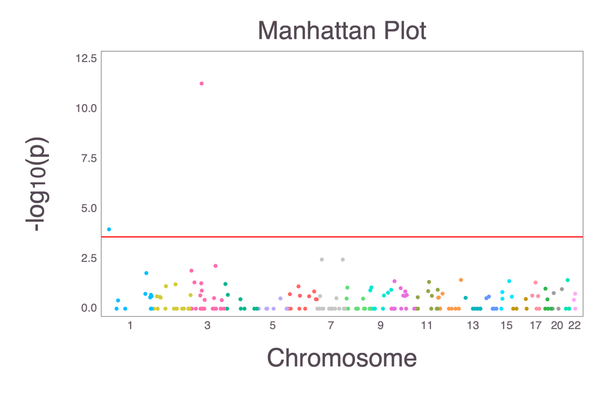

```julia
display("image/png", read("exactVC_eRLRT_manhattan.png"))
```

#### eLRT

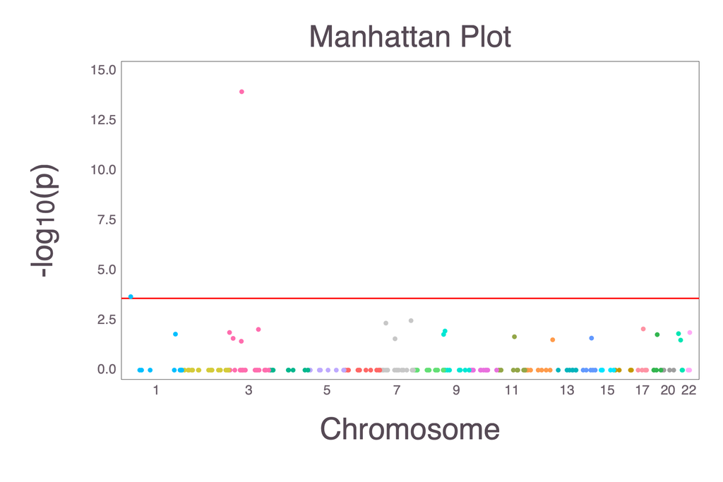

```julia
display("image/png", read("exactVC_eLRT_manhattan.png"))
```

#### eScore

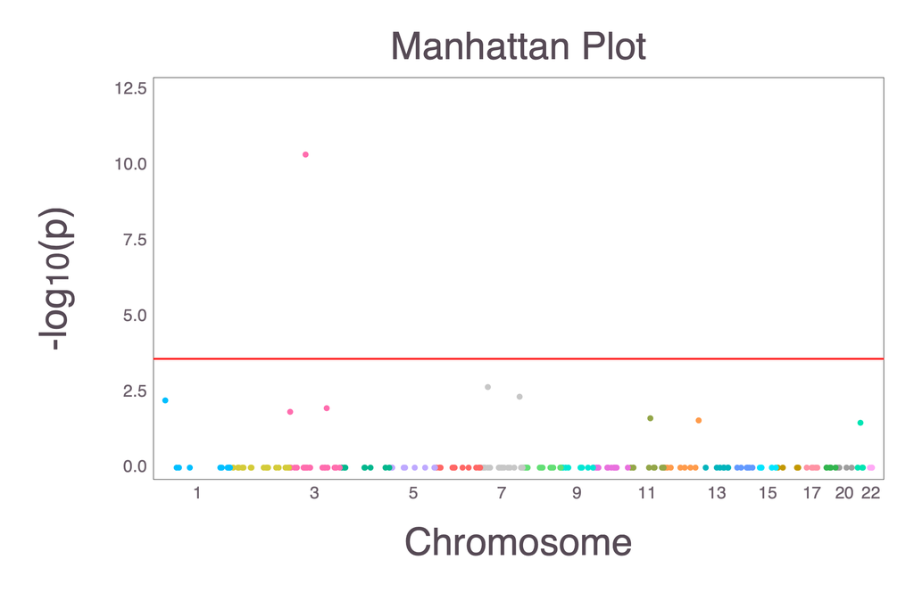

```julia
display("image/png", read("exactVC_eScore_manhattan.png"))
```